# Usage report Privacy Basics for Researchers

- Show All Code
- Hide All Code
- View Source

Author

Research Data Management Support

Published

July 2, 2024

## 1 About

In this report, you’ll find some data on the usage of the online training “Privacy Basics for Researchers”. This online module was created by Research Data Management Support at Utrecht University (NL) to provide a researcher-friendly introduction into the General Data Protection Regulation (GDPR), with a focus on how it applies to scientific research performed at Utrecht University (UU).

A description of and a registration link to the online module can be found on the [RDM Support website](https://www.uu.nl/en/research/research-data-management/walk-in-hours-workshops/privacy-basics-online-training). The module is embedded within the Utrecht University Moodle platform, “ULearning”, but the raw module materials are also available [online via Zenodo](https://doi.org/10.5281/zenodo.7930571).

**Note**

This report is primarily meant for internal monitoring purposes at the moment. We may adjust this report in a later stage, or move it to another web address!

## 2 Getting, reading and cleaning the data

### 2.1 Downloading the data

To obtain the data for this report from the ULearning platform, the following steps should be followed by a teacher/administrator in the ULearning platform:

##### 2.1.0.1 0. Add Groups to participants

1. From course main page, go to Participants.
2. Set the following selection criteria: Match Any - *Groups* - *No Groups*
3. Click “Apply filters”
4. Assign the participants that appear (if any) to the correct group, by clicking the pencil icon in the Groups column for that participant:
- `@students.uu.nl` should get “Student”
- `@umcutrecht.nl` should get “MED”
- `@uu.nl` email addresses: go to the [Employees page](https://intranet.uu.nl/en/search-a-colleague?search_type=FindByName&search_value) on intranet and search for their name or email address. Use the abbreviation of the faculty in which they are listed on the intranet.
- Other email addresses get “External”

##### 2.1.0.2 1. List of enrolled participants

1. From course main page, go to Participants.
2. Set the following selection criteria: Match *All* of the following
   - Match ANY Roles: Student, Guest, Authenticated user, Authenticated user on site home AND
   - Match None Groups: Red
3. Click “Apply filters”
4. Select all users
5. Under “With selected users…”, select “Comma-separated values (.csv)”
6. Save the file in the `raw` folder. Add the date of downloading in the downloaded csv file “YYYYMMDD_courseid_838_participants.csv”

##### 2.1.0.3 2. Progress report

1. From course main page, go to Reports > Activity completion
2. Download the file to the spreadsheet format (UTF-8 .csv)
3. Save the file in the `raw` folder. Add the date of downloading in the downloaded csv file “YYYYMMDD_progress.pbfr.csv”

##### 2.1.0.4 3. Quiz results

1. From course main page, go to “Chapter 6 | Closing” > “Final Quiz”
2. Click “Attempts: [##]” (The ## indicating the number of attempts)
3. Under What to include in the report, select:
   - Attempts from enrolled users who have attempted the quiz
   - Attempts that are In progress, Overdue, Finished, and Never submitted
   - Check Show at most one finished attempt per user (Highest grade)
4. Under Display options:
   - Make sure Page size is larger than the amount of attempts.
   - Marks for each question: Yes
5. Click Show report.
6. Select all participants using the checkbox above the first name in the list.
7. Download the data as Comma separated values (.csv)
8. Save the file in the `raw` folder as “YYYYMMDD_PBfR-Quiz.csv”.

The raw data are not shared because they contain personal data (e.g., names, email addresses and information about participants’ progress in the module).

### 2.2 Reading and cleaning the data

We first have to read and clean the data to get usable data frames. We don’t want to include people who were involved in the creation of the course or who provided feedback on it; we only need the actual users; people who enrolled after the launch of the course with the intention to actually learn something new!

**Code to load dependencies**

```r
library(tidyverse)
library(data.table)
library(kableExtra)
```

**Code to style graphs**

```r
# UU colors: https://www.uu.nl/en/organisation/corporate-identity/brand-policy/colour
UU_pallette <- c(
  "#FFE6AB", # Lighter yellow
  "#FFCD00", # UU yellow
  "#F3965E", # Orange
  "#C00A35", # Red
  "#AA1555", # Bordeaux-red
  "#6E3B23", # Brown
  "#24A793", # Green
  "#5287C6", # Blue
  "#001240", # Dark blue
  "#5B2182", # Purple
  "#000000" # Black
  )

uucol <- "#FFCD00"

styling <- list(
  theme_classic(),
  theme(legend.text = element_text(size = 10),
        legend.position = "bottom",
        legend.title = element_blank(),
        axis.title.x = element_text(size = 11),
        axis.text.y = element_text(size = 11),
        axis.ticks = element_blank(),
        panel.background = element_blank(),
        panel.border=element_blank(),
        panel.grid.major=element_blank(),
        panel.grid.minor=element_blank(),
        plot.background=element_blank())
)
```

**Code to read data**

```r
# 1. Read existing processed files
avg_progress_cats <- read.csv("data/processed/avg_progress_cats.csv")
nr_participants <- read.csv("data/processed/nr_participants.csv")
quizscores <- read.csv("data/processed/quizscores.csv")
total_quiz_scores <- read.csv("data/processed/total_quiz_scores.csv")

# 2. Read latest raw files
# See which files are in the raw folder
data_files <- data.frame(filename = list.files(path = "data/raw", pattern = ".csv"))

# Get the dates from the file names
data_files$filenamedates <- as.Date(str_extract(pattern = "[0-9]+[0-9]+[0-9]+",
                                                string = data_files$filename),
                                    format = "%Y%m%d")

# Sort by date using data.table::setorder (descending = most recent files first)
setorder(data_files, filenamedates, na.last = FALSE)

# Read the 3 files from the most recent date
participants <- read.csv(paste0("data/raw/",
                                data_files$filename[
                                  str_detect(data_files$filename[1:3],
                                             "courseid_838_participants.csv")
                                  ]))
progress <- read.csv(paste0("data/raw/",
                            data_files$filename[
                              str_detect(data_files$filename[1:3],
                                         "progress.pbfr.csv")
                            ]))
quiz <- read.csv(paste0("data/raw/",
                        data_files$filename[
                          str_detect(data_files$filename[1:3],
                                     "PBfR-Quiz.csv")
                        ]))

# Save the date for the coming calculations
date <- as.Date(data_files$filenamedates[1], "%Y-%m-%d")
```

**Code to select only relevant participants**

```r
# Filter participants to only contain the correct participants
participants_2 <- participants %>% filter(!(Groups == "Red" & !is.na(Groups)))

# Filter progress and quiz dataframes based on participants
progress_2 <- progress %>% semi_join(select(participants_2,
                                          Email.address),
                                     by = join_by(Email.address)) %>%
  # Also add Groups
  left_join(select(participants_2, Groups, Email.address))

quiz_2 <- quiz %>% semi_join(select(participants_2,
                                          Email.address),
                             by = join_by(Email.address)) %>%
  # Also add Groups
  left_join(select(participants_2, Groups, Email.address))
```

## 3 Number of participants

**Code to calculate the number of participants**

```r
# Calculate nr of participants of most recent download
new_row <- data.frame(date = date,
                      total = dim(participants_2)[1],
                      uu = sum(grepl("@uu.nl$",
                                     participants_2$Email.address)),
                      uu_students = sum(grepl("@students.uu.nl$",
                                              participants_2$Email.address)),

                      # other = total - uu - students
                      other = dim(participants_2)[1] -
                        sum(grepl("@uu.nl$", participants_2$Email.address)) -
                        sum(grepl("@students.uu.nl$", participants_2$Email.address)),

                      # Faculties
                      DGK = sum(participants_2$Groups=="DGK"),
                      REBO = sum(participants_2$Groups=="REBO"),
                      FSW = sum(participants_2$Groups=="FSW"),
                      GEO = sum(participants_2$Groups=="GEO"),
                      GW = sum(participants_2$Groups=="GW"),
                      BETA = sum(participants_2$Groups=="BETA"),
                      MED = sum(participants_2$Groups=="MED"),
                      UB = sum(participants_2$Groups=="UB"),
                      UBD = sum(participants_2$Groups=="UBD"),
                      Student = sum(participants_2$Groups=="Student"),
                      External = sum(participants_2$Groups=="External")
)

# Convert date to date type
nr_participants$date <- as.Date(nr_participants$date, "%Y-%m-%d")

# Paste new row below the existing data
nr_participants_all <- rbindlist(list(nr_participants, new_row),
                                     use.names = TRUE,
                                     fill = TRUE)
```

As of 2024-07-02, there are 141 participants enrolled in the course. 88 of them are enrolled with their “@uu.nl” email address, and 31 of them with the “@students.uu.nl” email address. 22 participants are either from an external institution or have used a personal email address to enroll in the course.

In the below bar chart, you can see the development of the number of participants in the course over time.

**Code to plot the participants over time**

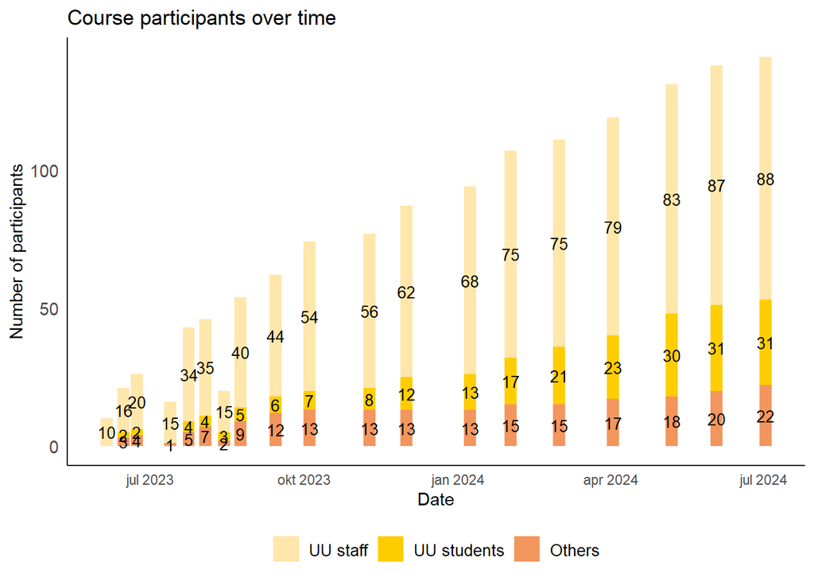

```r
# From wide to long
nr_participants_long <- pivot_longer(data = nr_participants_all,
                                    cols = c(uu, uu_students, other)
                                    #names_to = "variable",
                                    #values_to = "value"
                                    )

# Set the order of the variable levels
nr_participants_long$name <- factor(nr_participants_long$name, levels = c("uu", "uu_students", "other"))

# Create a stacked bar plot
# Calculate midpoints for label positioning
nr_participants_long <- nr_participants_long %>%
  group_by(date) %>%
  arrange(desc(name)) %>%
  mutate(midpoint = cumsum(value) - 0.5 * value,
         prev_height = lag(cumsum(value), default = 0))

# Adjust y-axis limits
y_max <- max(nr_participants_long$midpoint) + max(nr_participants_long$value) / 2

# Adjust label positioning
ggplot(nr_participants_long, aes(x = date, y = value, fill = name)) +
  geom_bar(stat = "identity") +
  geom_text(aes(label = ifelse(value > 0, value, ""),
                y = prev_height + value / 2, group = name),
            vjust = 0.5, color = "black", size = 3.5) +
  ylim(0, y_max) +  # Set y-axis limits
  labs(title = "Course participants over time",
       x = "Date", y = "Number of participants",
       fill = "Type of participant") +
  scale_fill_manual(name = "Group",
                    labels = c("uu" = "UU staff",
                               "uu_students" = "UU students",
                               "other" = "Others"),
                    values = UU_pallette) +
  styling
```

## 4 Participation per faculty

On 2024-07-02, this was the division of faculties in the module (total: 141):

**Code to create a table of participation per faculty**

```r
# Select the faculties and total values per date
nrs_faculties <- nr_participants_all %>%
  select(date, DGK:External, total) %>%
  filter(!is.na(DGK))

# make a long dataframe
nrs_faculties_long <- nrs_faculties %>%
  pivot_longer(cols = -date,
               names_to = "Faculty",
               values_to = "Participants") %>%
  mutate(date = as.character(date))

# make it wide again so that the df is in the right format for the table
nrs_faculties_wide <- nrs_faculties_long %>%
  pivot_wider(names_from = date,
              values_from = Participants)

# Create the table with kableExtra
kable(nrs_faculties_wide, format = "html", output = FALSE,
              caption = "<b>Participants per faculty</b>",
              table.attr='cellpadding="3", cellspacing="3"') %>%
    kable_styling(bootstrap_options = c("striped",
                                        "hover",
                                        "condensed",
                                        "responsive"),
                  fixed_thead = T) %>%
  # Highligh the last row (total) in yellow and bold
  # Source: https://haozhu233.github.io/kableExtra/awesome_table_in_html.html
    row_spec(length(nrs_faculties_wide$Faculty),
             bold = T, color = "black", background = uucol)
```

**Participants per faculty**

| Faculty | 2024-01-08 | 2024-02-01 | 2024-03-01 | 2024-04-02 | 2024-05-07 | 2024-06-03 | 2024-07-02 |
| --- | --- | --- | --- | --- | --- | --- | --- |
| DGK | 15 | 16 | 16 | 16 | 16 | 17 | 17 |
| REBO | 6 | 7 | 7 | 7 | 7 | 7 | 7 |
| FSW | 18 | 21 | 21 | 21 | 21 | 22 | 22 |
| GEO | 2 | 3 | 4 | 5 | 6 | 7 | 8 |
| GW | 9 | 9 | 9 | 11 | 13 | 13 | 13 |
| BETA | 13 | 16 | 16 | 16 | 17 | 18 | 18 |
| MED | 4 | 4 | 4 | 4 | 4 | 4 | 4 |
| UB | 4 | 4 | 4 | 4 | 4 | 4 | 4 |
| UBD | 1 | 2 | 2 | 3 | 3 | 3 | 3 |
| Student | 13 | 14 | 17 | 19 | 26 | 27 | 27 |
| External | 9 | 11 | 11 | 13 | 14 | 16 | 18 |
| total | 94 | 107 | 111 | 119 | 131 | 138 | 141 |

## 5 Participants’ progress

Below you can see the average progress per group of participants for each block in the course as of 2024-07-02.

**Code to plot latest progress per chapter and group**

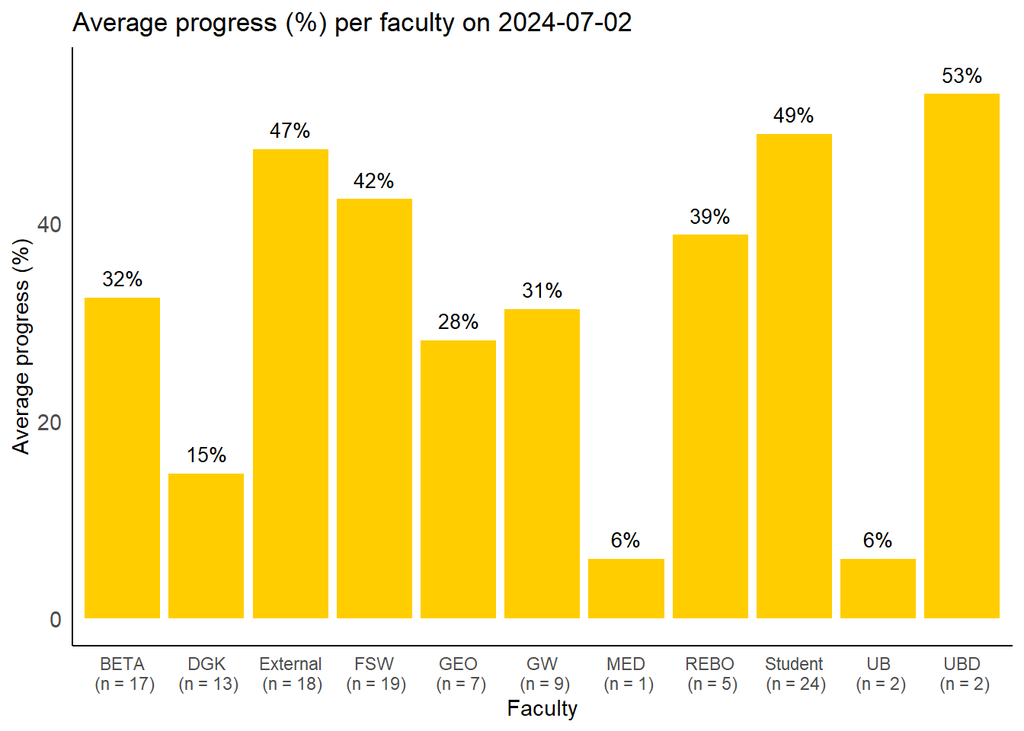

```r
progress_3 <- progress_2 %>%
  # Delete columns we won't use
  select(-starts_with("X")) %>%
  # Turn character completion into numeric 0 or 1
  mutate_at(vars(-Email.address, -Groups),
            ~ifelse(. == "Completed", 1, 0)) %>%
  # Turn Groups variable into a factor
  mutate(Groups = factor(Groups,
                         levels = c("DGK", "REBO", "FSW", "GEO", "GW",
                                    "BETA", "MED", "UB", "UBD",
                                    "Student", "External")),
         #Create a factor variable for alternative group membership (UU, student or other)
         group = as.factor(ifelse(grepl("@uu.nl$",
                                        Email.address),
                                  "uu",
                                  ifelse(grepl("@students.uu.nl$",
                                               Email.address),
                                         "uu_students",
                                         "other"))))

# Set order of the factor levels
progress_3$group <- factor(progress_3$group,
                           levels = c("uu", "uu_students", "other"))

# Group blocks into sections for easier visualization
latest_progress_long <- progress_3 %>%
  pivot_longer(cols = -c(Email.address, Groups, group),
               names_to = "block",
               values_to = "completion") %>%
  mutate(chapter = ifelse(startsWith(block, "Welcome") |
                            startsWith(block, "Introduction.to.Personal.Data.under.the.GDPR") |
                            startsWith(block, "GDPR") |
                            startsWith(block, "What.is.Personal.Data") |
                            startsWith(block, "Special.Categories.of.Personal.Data") |
                            startsWith(block, "Roles.in.the.GDPR"),
                          "Chapter 1", ifelse(
                            startsWith(block, "Introduction.to.Lawfulness") |
                              startsWith(block, "Legal.Basis.for.Processing.Data") |
                              startsWith(block, "Public.Interest") |
                              startsWith(block, "Consent") |
                              startsWith(block, "How.to.Inform.Data.Subjects") |
                              startsWith(block, "Data.Subject.Rights"),
                            "Chapter 2", ifelse(
                              startsWith(block, "Introduction.to.Planning.Your.Project") |
                                startsWith(block, "Privacy.by.Design.and.Privacy.by.Default") |
                                startsWith(block, "Demonstrating.Compliance") |
                                startsWith(block, "Privacy.Scan.and.DPIA") |
                                startsWith(block, "Common.Privacy.Risks") |
                                startsWith(block, "Reporting.a.Data.Breach"),
                              "Chapter 3", ifelse(
                                startsWith(block, "Introduction.to.Practical.Measures") |
                                  startsWith(block, "Levels.of.Data.Security") |
                                  startsWith(block, "Access.Control") |
                                  startsWith(block, "Encryption") |
                                  startsWith(block, "Pseudonymisation.and.Anonymisation") |
                                  startsWith(block, "De.identification.in.Practice") |
                                  startsWith(block, "Processing.Tools"),
                                "Chapter 4", ifelse(
                                  startsWith(block, "Introduction.to.Storing.and.Sharing.Personal.Data") |
                                    startsWith(block, "Storing.Personal.Data") |
                                    startsWith(block, "Agreements.in.Research") |
                                    startsWith(block, "Sharing.Personal.Data") |
                                    startsWith(block, "Making.Personal.Data.FAIR"),
                                  "Chapter 5", ifelse(
                                    startsWith(block, "Final.Quiz") |
                                      startsWith(block, "Evaluate.this.course") |
                                            startsWith(block, "Available.Support.at.Utrecht.University"),
                                    "Chapter 6", "Not assigned"
                                  )
                                )
                              )
                            )
                          )
  )
  )


# Count people per faculty who appear in the progress file
n <- progress_3 %>% count(Groups)

# Save completion rate per faculty
progress_per_fac <- latest_progress_long %>%
  group_by(Groups) %>%
  summarise(avg_completion_rate = mean(completion) * 100) %>%
  left_join(n) %>%
  mutate(date = date)

# Plot progress per faculty
progress_per_fac %>%
  mutate(graph_label = paste0(Groups, "\n (n = ", n, ")")) %>%
  ggplot(aes(x = graph_label,
             y = avg_completion_rate)) +
  geom_bar(stat = "identity",
           position = position_dodge(0.9),
           fill = uucol) +
  geom_text(aes(label = paste0(round(avg_completion_rate, 0), "%"),
                y = avg_completion_rate + 2),  # Adjust label position as needed
            size = 3.5, color = "black", position = position_dodge(0.9)) +
  labs(x = "Faculty", y = "Average progress (%)",
       title = paste0("Average progress (%) per faculty on ", date)) +
  styling
```

**See R code**

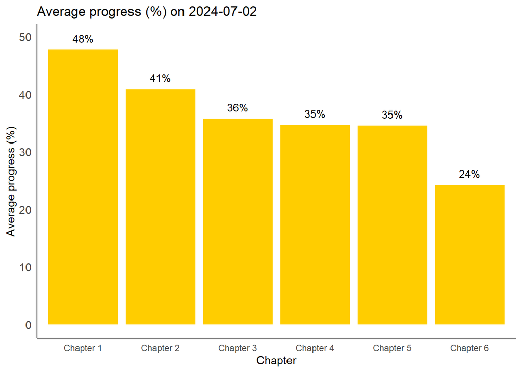

```r
# Plot average progress score (per person) per chapter
latest_progress_long %>%
  group_by(chapter) %>%
  summarise(avg_completion_rate = mean(completion)) %>%
  ungroup() %>%
  ggplot(aes(x = chapter,
             y = avg_completion_rate * 100)) +
  geom_bar(stat = "identity",
           position = position_dodge(0.9),
           fill = uucol) +
  geom_text(aes(label = paste0(round(avg_completion_rate * 100, 0), "%"),
                y = avg_completion_rate * 100 + 2),  # Adjust label position as needed
            size = 3.5, color = "black", position = position_dodge(0.9)) +
  labs(x = "Chapter", y = "Average progress (%)",
       title = paste0("Average progress (%) on ", date)) +

  styling
```

Below, you can see the average progress over time. On July 11th, the ULearning platform got an update. Therefore, from then onwards, the progress for every user was set to 0 again, hence the drop in progress in July 2023.

**Code to plot average progress over time**

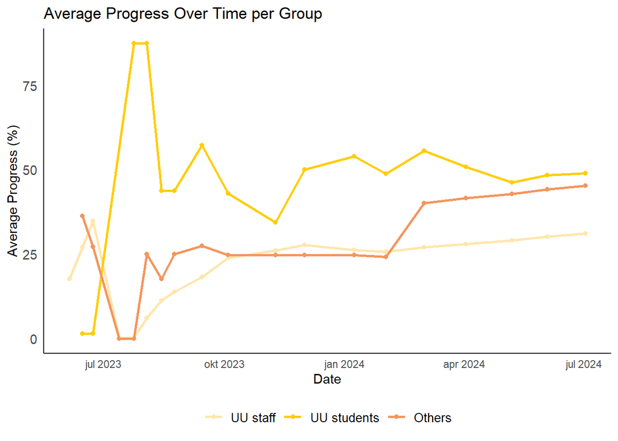

```r
progress_4_fac <- progress_3 %>%
# From wide to long format based on the Email address and group
    pivot_longer(cols = -c(Email.address, Groups, group),
                 names_to = "block",
                 values_to = "completion") %>%
    group_by(Email.address, Groups) %>%
    # Calculate average completion rate per participant
    summarise(progress = mean(completion)) %>%
    # Put date in a new date column for all rows in the dataframe
    mutate(date = as.Date(rep(date, n())))

progress_4_group <- progress_3 %>%
# From wide to long format based on the Email address and group
    pivot_longer(cols = -c(Email.address, Groups, group),
                 names_to = "block",
                 values_to = "completion") %>%
    group_by(Email.address, group) %>%
    # Calculate average completion rate per participant
    summarise(progress = mean(completion)) %>%
    # Put date in a new date column for all rows in the dataframe
    mutate(date = as.Date(rep(date, n())))

# Calculate new progress per faculty dataframe
avg_progress_new_fac <- progress_4_fac %>%
  group_by(Groups, date) %>%
  summarise(n = n(), # nr of people underlying each average
            avg_progress = mean(progress) * 100)

# Calculate new progress per group dataframe
avg_progress_new_group <- progress_4_group %>%
  group_by(group, date) %>%
  summarise(n = n(), # nr of people underlying each average
            avg_progress = mean(progress) * 100)

# In the old dataframe, make date as actual date + make group a factor
avg_progress_cats$date <- as.Date(avg_progress_cats$date, "%Y-%m-%d")
avg_progress_cats$group <- factor(avg_progress_cats$group,
                                  levels = c("uu",
                                             "uu_students",
                                             "other"))

# Combine old and new data in 1 dataframe
avg_progress_cats_new <- bind_rows(avg_progress_cats,
                                   avg_progress_new_fac,
                                   avg_progress_new_group)

# Plot average progress over time per group
avg_progress_cats_new[!is.na(avg_progress_cats_new$group),] %>%
  ggplot(aes(x = date,
             y = avg_progress,
             color = group)) +
  geom_point() +
  geom_line(linewidth = 1) +
  labs(x = "Date",
       y = "Average Progress (%)",
       title = "Average Progress Over Time per Group") +
  scale_color_manual(name = "Group",
                      labels = c("uu" = "UU staff",
                                 "uu_students" = "UU students",
                                 "other" = "Others"),
                    values = UU_pallette) +
  styling
```

## 6 Quiz results

**Code to clean the new quiz data**

```r
quiz_3 <- quiz_2 %>%
  # Remove duplicate rows in the dataset: take Finished if the participant has
  # both a State = Finished and In progress.
  group_by(Last.name) %>%
  mutate(has_finished = any(State == "Finished")) %>%
  filter(!((State == "In progress" | State == "In Progress") & has_finished)) %>%
  select(-has_finished)

# Make character grades numeric, and "-" into NA
quiz_3[quiz_3 == "-"] <- NA
quiz_3 <- quiz_3 %>%
  mutate(Grade = as.numeric(Grade.10.0)) %>%
  mutate_at(vars(starts_with("Q..")),
            as.numeric)

# Create a factor variable for group membership (UU, student or other)
quiz_3$group <- as.factor(ifelse(grepl("@uu.nl$",
                                       quiz_3$Email.address),
                                 "uu",
                                 ifelse(grepl("@students.uu.nl$",
                                              quiz_3$Email.address),
                                        "uu_students",
                                        "other")))

# Rename question columns into something human-readable
colnames(quiz_3) <- gsub("^Q\\.\\.([0-9]+)\\.\\..*",
                         "Q\\1",
                         names(quiz_3))

# Summarize the new quiz data per group
quiz_4 <- quiz_3 %>%
  # Make sure group is a factor variable
  mutate(group = factor(group, levels = c("uu",
                                          "uu_students",
                                          "other"))) %>%
  # Group by UU / Students / Other / All for summary calculations
  group_by(group) %>%
  # For every group, save the sample size, total grade, and mean grade per question
  summarise(
    n = n(),
    total_grade = mean(Grade, na.rm = TRUE),
    across(starts_with("Q"),
           ~ mean(., na.rm = TRUE)/0.6*100)
  ) %>%
  # Also save the date in the dataframe
  mutate(date = as.Date(date, "%Y-%m-%d")) %>%
  # Rearrange the columns for easier readability
  select(date, group, n, total_grade, starts_with("Q"))

# Summarize the new quiz data per faculty
quiz_4_fac <- quiz_3 %>%
  # Group by faculty for summary calculations
  group_by(Groups) %>%
  # For every faculty, save the sample size, total grade, and mean grade per question
  summarise(
    n = n(),
    total_grade = mean(Grade, na.rm = TRUE),
    across(starts_with("Q"),
           ~ mean(., na.rm = TRUE)/0.6*100)
  ) %>%
  # Also save the date in the dataframe
  mutate(date = as.Date(date, "%Y-%m-%d")) %>%
  # Rearrange the columns for easier readability
  select(date, Groups, n, total_grade, starts_with("Q"))


# Summarize new quiz data total (not per group)
quiz_4_total <- quiz_3 %>%
  ungroup() %>%
  # Save the sample size, total grade, and mean grade per question
  summarise(
    n = sum(!is.na(Grade)),
    total_grade = mean(Grade, na.rm = TRUE),
    across(starts_with("Q"), ~mean(., na.rm = TRUE) / 0.6 * 100)
  ) %>%
  # Also save the date in the dataframe
  mutate(date = as.Date(date, "%Y-%m-%d")) %>%
  # Rearrange the columns for easier readability
  select(date, n, total_grade, starts_with("Q"))

# Make date variables in old dataframes date too in order to merge
quizscores$date <- as.Date(quizscores$date, "%Y-%m-%d")
total_quiz_scores$date <- as.Date(total_quiz_scores$date, "%Y-%m-%d")

# Append new quizscores to old quiz scores
quizscores_new <- bind_rows(quizscores, quiz_4, quiz_4_fac)
quizscores_new$group <- factor(quizscores_new$group,
                                  levels = c("uu",
                                             "uu_students",
                                             "other"))

total_quiz_scores_new <- bind_rows(total_quiz_scores, quiz_4_total)
```

Below you can see the average final score on the quiz for the latest quiz results.

**Code to plot the latest final grade per faculty**

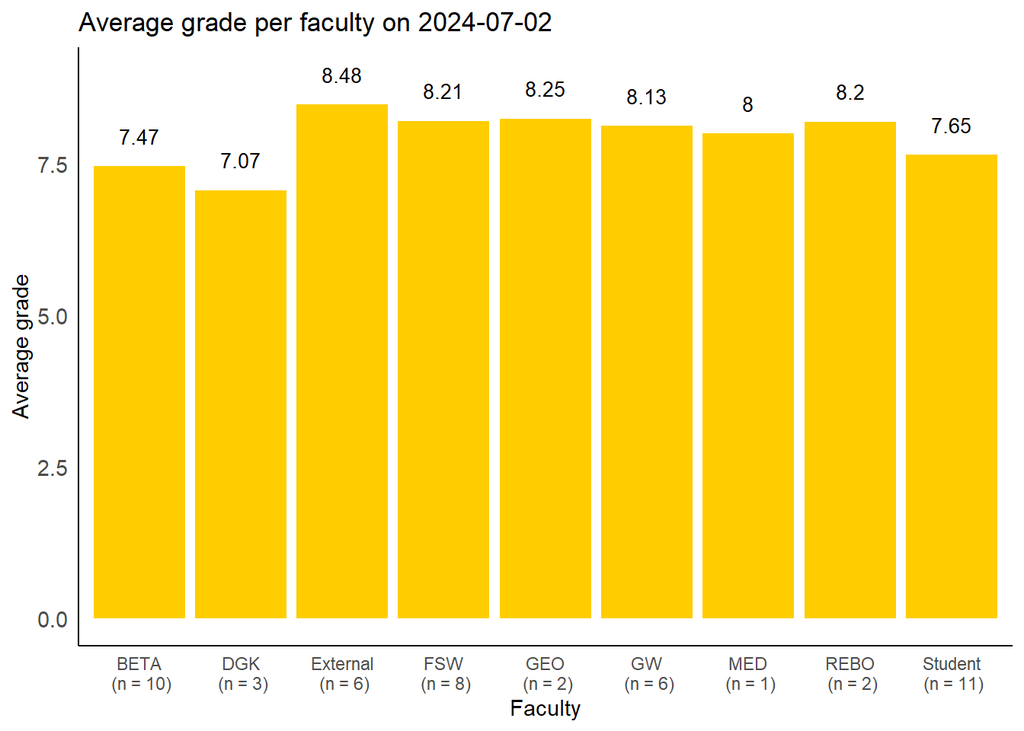

```r
quiz_4_fac %>%
  mutate(graph_label = paste0(Groups, "\n (n = ", n, ")")) %>%
  ggplot(aes(x = graph_label,
             y = total_grade)) +
  geom_bar(stat = "identity",
           position = position_dodge(0.9),
           fill = uucol) +
  geom_text(aes(label = round(total_grade, 2),
                y = total_grade + 0.5),  # Adjust label position as needed
            size = 3.5, color = "black", position = position_dodge(0.9)) +
  labs(x = "Faculty", y = "Average grade",
       title = paste0("Average grade per faculty on ", date)) +
  styling
```

**Code to create the plot per question**

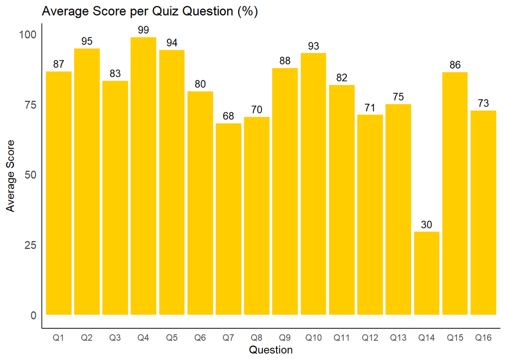

```r
latestquiz_total_long <- quiz_4_total %>%
  select(starts_with("Q")) %>%
  gather(key = "Question", value = "Score")

# Convert "Question" to a factor with the correct order
latestquiz_total_long$Question <- factor(latestquiz_total_long$Question,
                                  levels = paste0("Q", 1:16))

# Plot
ggplot(latestquiz_total_long, aes(x = Question,
                            y = Score)) +
  geom_bar(stat = "identity", fill = uucol) +
  labs(x = "Question",
       y = "Average Score",
       title = "Average Score per Quiz Question (%)") +
  geom_text(aes(label = sprintf("%.0f", Score)), vjust = -0.5, size = 3.5) +
  styling
```

Below you can find the number of attempts (either in Progress or Finished)

**Code to plot the number of attempts over time**

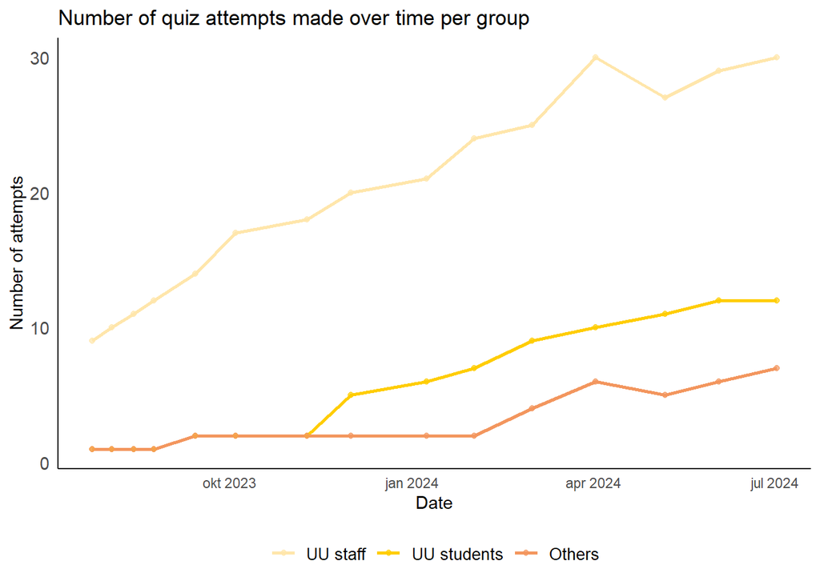

```r
quizscores_attempts <- quizscores_new %>%
  select(date,
         group,
         n) %>%
  filter(!is.na(group))

# Line plot
quizscores_attempts %>%
  ggplot(aes(x = date, y = n, color = group)) +
  geom_line(linewidth = 1) +
  geom_point(alpha = 0.7) +
  labs(x = "Date",
       y = "Number of attempts",
       title = "Number of quiz attempts made over time per group") +
  scale_color_manual(values = UU_pallette,
                     name = "Group",  # Set the legend title
                     labels = c("uu" = "UU staff",
                                "uu_students" = "UU students",
                                "other" = "Others")) +  # Set the legend labels
  styling
```

**Code to write new objects to the processed folder**

```r
# number of participants
write.csv(nr_participants_all,
          "data/processed/nr_participants.csv",
          row.names = FALSE)

# progress
write.csv(avg_progress_cats_new,
          "data/processed/avg_progress_cats.csv",
          row.names = FALSE)

# quiz
write.csv(quizscores_new,
          "data/processed/quizscores.csv",
          row.names = FALSE)
write.csv(total_quiz_scores_new,
          "data/processed/total_quiz_scores.csv",
          row.names = FALSE)
```